# Clean Data

Author

Maximilian Rohde

Published

March 10, 2026

```r
library(tidyverse)
library(data.table)
```

```r
# Load in raw LHS data from Jonathan
load("lhsRohde.Rdata")
df <- lhsRohde
```

```r
# Check the overall data structure
Hmisc::describe(df)
```

```
df

 75  Variables      11196  Observations
----------------------------------------------------------------------------------------------------------------------------------------------------------------
id
       n  missing distinct     Info     Mean  pMedian      Gmd      .05      .10      .25      .50      .75      .90      .95
   11196        0     2562        1   373210   376294     7350   374392   374608   375206   376330   377382   377978   378197

Value      295000 374000 375000 376000 377000 378000
Frequency     441   1795   2580   2600   2721   1059
Proportion  0.039  0.160  0.230  0.232  0.243  0.095

For the frequency table, variable is rounded to the nearest 1000
----------------------------------------------------------------------------------------------------------------------------------------------------------------
visit
       n  missing distinct     Info     Mean  pMedian      Gmd
   11196        0        5    0.959    2.901        3    1.594

Value          1     2     3     4     5
Frequency   2419  2432  2232  2063  2050
Proportion 0.216 0.217 0.199 0.184 0.183
----------------------------------------------------------------------------------------------------------------------------------------------------------------
fev
       n  missing distinct     Info     Mean  pMedian      Gmd      .05      .10      .25      .50      .75      .90      .95
   11196        0      361        1    2.628     2.62   0.7485     1.60     1.77     2.13     2.61     3.11     3.49     3.72

lowest : 0.74 0.79 0.81 0.84 0.85, highest: 4.62 4.66 4.7  4.72 4.75
----------------------------------------------------------------------------------------------------------------------------------------------------------------
fevpct
       n  missing distinct     Info     Mean  pMedian      Gmd      .05      .10      .25      .50      .75      .90      .95
   11196        0      613        1     75.9     76.4    12.28    56.48    60.90    68.90    77.10    83.90    89.00    91.70

lowest : 31.6  33.2  33.6  35.1  35.5 , highest: 106.4 106.5 106.9 108.3 108.5
----------------------------------------------------------------------------------------------------------------------------------------------------------------
fvc
       n  missing distinct     Info     Mean  pMedian      Gmd      .05      .10      .25      .50      .75      .90      .95
   11196        0      482        1    4.175    4.165    1.105     2.67     2.89     3.39     4.18     4.90     5.44     5.74

lowest : 1.42 1.67 1.8  1.81 1.83, highest: 6.89 6.98 7.03 7.16 7.18
----------------------------------------------------------------------------------------------------------------------------------------------------------------
```

[output cut: 403 more lines]

```

----------------------------------------------------------------------------------------------------------------------------------------------------------------
site10
       n  missing distinct     Info      Sum     Mean
   11196        0        2    0.197      791  0.07065

----------------------------------------------------------------------------------------------------------------------------------------------------------------
n.obs
       n  missing distinct     Info     Mean  pMedian      Gmd
   11196        0        4    0.564    4.599        5   0.6528

Value          2     3     4     5
Frequency    480   798  1448  8470
Proportion 0.043 0.071 0.129 0.757
----------------------------------------------------------------------------------------------------------------------------------------------------------------
```

## SNP columns

```r
# Identify the SNP columns -- start with "rs"
snps <- select(df, dplyr::starts_with("rs"))
```

```r
print(ncol(snps))
```

```
[1] 43
```

```r
if (anyNA(snps)) {
    cli::cli_abort("Some subjects have missing SNP values.")
}
```

# Data Cleaning

```r
# Threshold SNP dosages to 0/1
snps <- mutate(snps, across(everything(), \(x) as.integer(x >= 0.5)))

# Mean of SNPs within each subject
df$x_mean <- rowMeans(snps)

# Sum of SNPs within each subject
df$x_count <- rowSums(snps) |> as.integer()
```

```r
df$fev1 <- df$fev
df$t <- df$visit
df$fev_fvc_ratio <- df$fev / df$fvc

# BMI change from baseline (time-varying)
df$bmi_change <- df$bmi - df$bmi0

# Covariates
df$age <- df$age / 10
df$packyear <- df$packyear / 10
df$f31cigs <- df$f31cigs / 10

# Rename IDS to be sequential integers
df$id <- as.integer(as.factor(df$id))

df$rs177852 <- as.integer(df$rs177852 >= 0.5)

df <-
  df |>
  select(id,
         x_mean,
         x_count,
         rs177852,
         fev1,
         t,
         fevpct,
         fvc,
         fev_fvc_ratio,
         bmi_change,
         age,
         packyear,
         f31cigs,
         female,
         bmi0,
         site)
```

```r
arrow::write_parquet(df,
                     sink = "lhs_cleaned.parquet")
```

## List of variables in output data

- **id**: Subject identifier (sequential integers, 1 to N)
- **x_mean**: Polygenic risk score — unweighted mean of 43 hard-called SNPs (proportion, k/43)
- **x_count**: Polygenic risk score — sum of 43 hard-called SNPs (integer count, 0–43)
- **rs177852**: Binary indicator for presence of >= 1 T allele at rs177852 (*TTC6* gene)
- **fev1**: FEV1 in liters (forced expiratory volume in 1 second)
- **t**: Visit number (1–5, corresponding to annual visits)
- **fevpct**: FEV1 percent predicted (longitudinal, one per visit)
- **fvc**: Forced vital capacity in liters (longitudinal, one per visit)
- **fev_fvc_ratio**: FEV1/FVC ratio (computed as `fev / fvc`, longitudinal)
- **bmi_change**: BMI change from baseline (time-varying, `bmi - bmi0` at each visit)
- **age**: Age at baseline in decades (original years / 10)
- **packyear**: Cumulative pack-years of smoking in tens (original pack-years / 10)
- **f31cigs**: Cigarettes smoked per day in the year before enrollment, in tens (original count / 10)
- **female**: Sex indicator (1 = female, 0 = male)
- **bmi0**: Baseline body mass index (kg/m<sup>2</sup>, unscaled)
- **site**: Clinical site indicator (1–10)

## Correlation matrix

```r
cor_mat <- df |>
    dplyr::distinct(id, .keep_all = TRUE) |>
    select(-id, -site) |>
    cor()

round(cor_mat, 3)
```

```
              x_mean x_count rs177852   fev1      t fevpct    fvc fev_fvc_ratio bmi_change    age packyear f31cigs female   bmi0
x_mean         1.000   1.000    0.109 -0.055 -0.019 -0.031 -0.058        -0.001      0.030 -0.023   -0.043  -0.001  0.064 -0.037
x_count        1.000   1.000    0.109 -0.055 -0.019 -0.031 -0.058        -0.001      0.030 -0.023   -0.043  -0.001  0.064 -0.037
rs177852       0.109   0.109    1.000 -0.013  0.002  0.005 -0.015        -0.004     -0.021 -0.007   -0.008  -0.026  0.026  0.000
fev1          -0.055  -0.055   -0.013  1.000 -0.025  0.600  0.890         0.310     -0.073 -0.347   -0.068   0.049 -0.698  0.161
t             -0.019  -0.019    0.002 -0.025  1.000 -0.025  0.000        -0.053     -0.010 -0.024    0.003  -0.003 -0.005  0.012
fevpct        -0.031  -0.031    0.005  0.600 -0.025  1.000  0.363         0.563     -0.078 -0.190   -0.190  -0.121  0.002 -0.029
fvc           -0.058  -0.058   -0.015  0.890  0.000  0.363  1.000        -0.145     -0.070 -0.243    0.004   0.065 -0.754  0.127
fev_fvc_ratio -0.001  -0.001   -0.004  0.310 -0.053  0.563 -0.145         1.000     -0.010 -0.241   -0.154  -0.030  0.064  0.078
bmi_change     0.030   0.030   -0.021 -0.073 -0.010 -0.078 -0.070        -0.010      1.000 -0.034   -0.023   0.013  0.053 -0.127
age           -0.023  -0.023   -0.007 -0.347 -0.024 -0.190 -0.243        -0.241     -0.034  1.000    0.387  -0.086  0.015 -0.003
packyear      -0.043  -0.043   -0.008 -0.068  0.003 -0.190  0.004        -0.154     -0.023  0.387    1.000   0.409 -0.178  0.083
f31cigs       -0.001  -0.001   -0.026  0.049 -0.003 -0.121  0.065        -0.030      0.013 -0.086    0.409   1.000 -0.142  0.062
female         0.064   0.064    0.026 -0.698 -0.005  0.002 -0.754         0.064      0.053  0.015   -0.178  -0.142  1.000 -0.259
bmi0          -0.037  -0.037    0.000  0.161  0.012 -0.029  0.127         0.078     -0.127 -0.003    0.083   0.062 -0.259  1.000
```

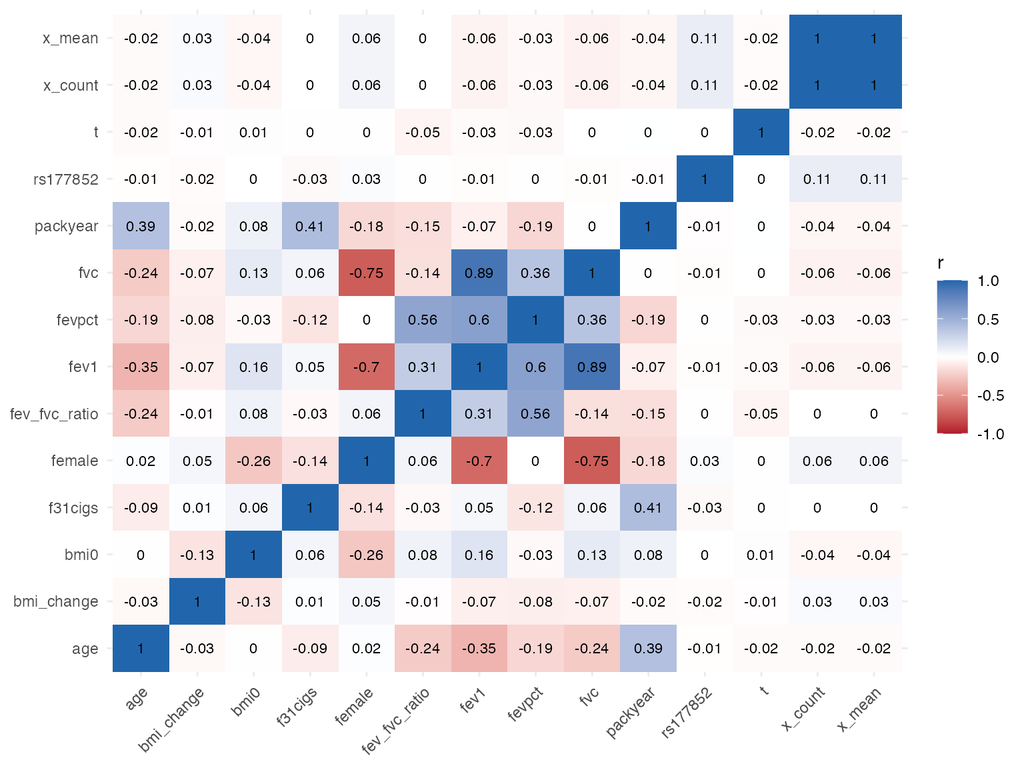

```r
cor_mat |>
    as.data.frame() |>
    tibble::rownames_to_column("var1") |>
    tidyr::pivot_longer(-var1, names_to = "var2", values_to = "cor") |>
    ggplot(aes(x = var1, y = var2, fill = cor)) +
    geom_tile() +
    geom_text(aes(label = round(cor, 2)), size = 3) +
    scale_fill_gradient2(low = "#B2182B", mid = "white", high = "#2166AC",
                         limits = c(-1, 1)) +
    theme_minimal() +
    theme(axis.text.x = element_text(angle = 45, hjust = 1)) +
    labs(x = NULL, y = NULL, fill = "r")
```

## Is the distribution of sum(SNPs) normal?

```r
plot_df <-
df |>
  distinct(id, .keep_all = TRUE)
```

### Histogram

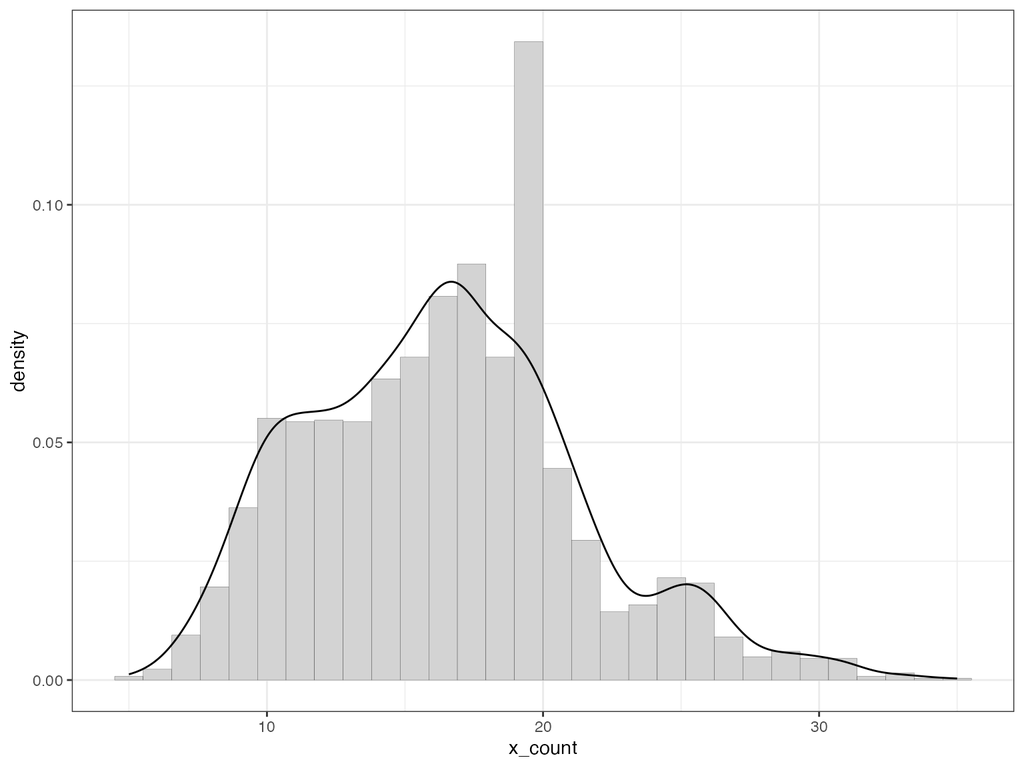

```r
plot_df |>
  ggplot() +
  aes(x = x_count) +
  geom_histogram(aes(y = after_stat(density)),
                 bins = 30,
                 color = "black",
                 fill = "lightgray",
                 linewidth = 0.05) +
  geom_density() +
  theme_bw()
```

### ECDF

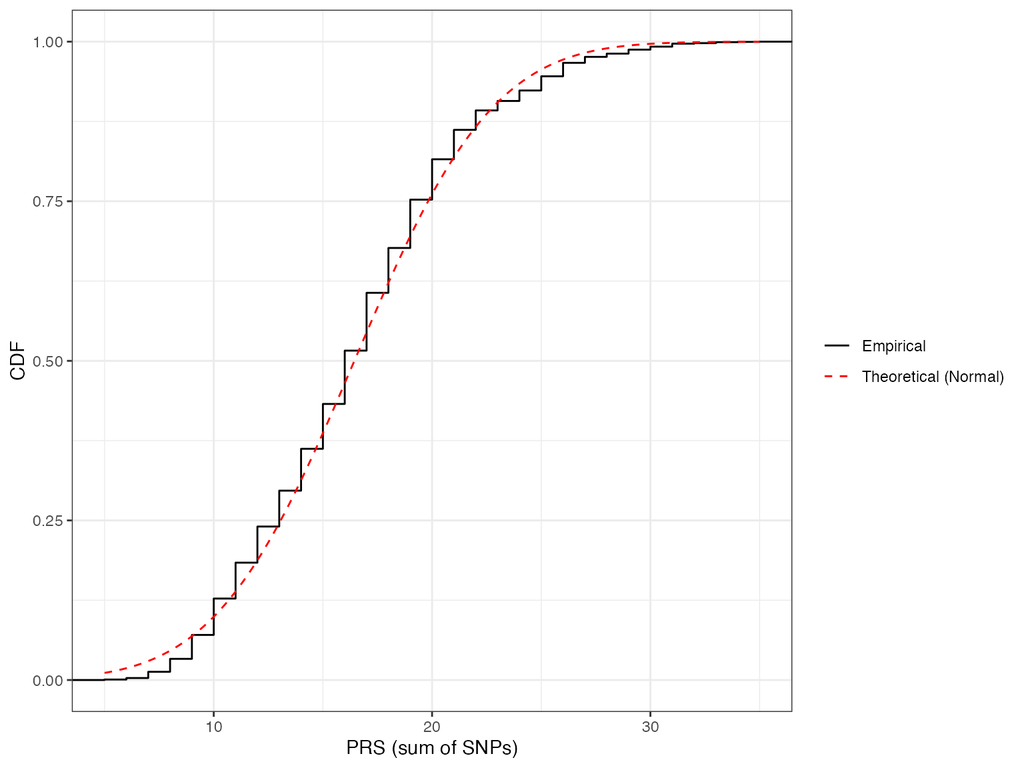

```r
mu <- mean(plot_df$x_count)
sigma <- sd(plot_df$x_count)

theoretical_df <- tibble(
    x_count = seq(min(plot_df$x_count), max(plot_df$x_count), length.out = 1000L),
    cdf = pnorm(x_count, mean = mu, sd = sigma)
)

ggplot(plot_df, aes(x = x_count)) +
    stat_ecdf(aes(color = "Empirical"), geom = "step") +
    geom_line(data = theoretical_df,
              aes(y = cdf, color = "Theoretical (Normal)"),
              linetype = "dashed") +
    scale_color_manual(values = c("Empirical" = "black",
                                  "Theoretical (Normal)" = "red")) +
    labs(x = "PRS (sum of SNPs)", y = "CDF", color = NULL) +
    theme_bw()
```